# Happiness in the Tidyverse

## Lying

Repeat the above analysis comparing how peoples’ happiness scores depend on their attitudes about lying.

1. Create a new dataset called `lying` that excludes the `#N/A` values in `Lying` and the Happiness scores outliers, and includes only “Happiness_score” and “Lying”:

```r
lying <- happiness %>%
  filter(Happiness_score <= 15,
         Happiness_score >= 0,
         Lying != "#N/A") %>%
  select(Lying, Happiness_score)
```

2. Create a side-by-side boxplot and summary statistics (using `favstats()`) table for each attitude about Lying:

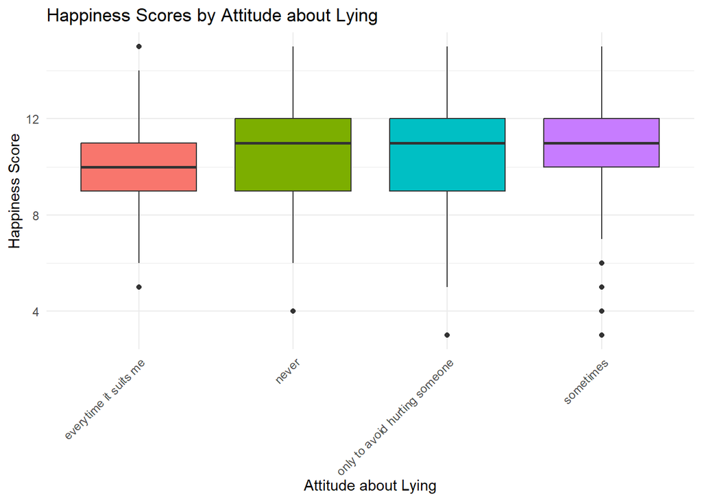

```r
ggplot(lying, aes(x = Lying, y = Happiness_score, fill = Lying)) +
  geom_boxplot() +
  labs(title = "Happiness Scores by Attitude about Lying",
       x = "Attitude about Lying",
       y = "Happiness Score") +
  theme_minimal() +
  theme(legend.position = "none",
        axis.text.x = element_text(angle = 45, hjust = 1))
```

```r
favstats(Happiness_score ~ Lying, data = lying)
```

```
                          Lying min Q1 median Q3 max     mean       sd   n
1         everytime it suits me   5  9     10 11  15 10.05839 2.175284 137
2                         never   4  9     11 12  15 10.80000 2.138090  50
3 only to avoid hurting someone   3  9     11 12  15 10.54444 1.997179 270
4                     sometimes   3 10     11 12  15 10.71639 1.764933 543
  missing
1       0
2       0
3       0
4       0
```

# Choose your own adventure

Pick another **categorical variable** with multiple groups that may impact happiness score.

Be sure to clean out any ‘nunya business’ or ‘#N/A’ that might be there and clean out the outliers in happiness:

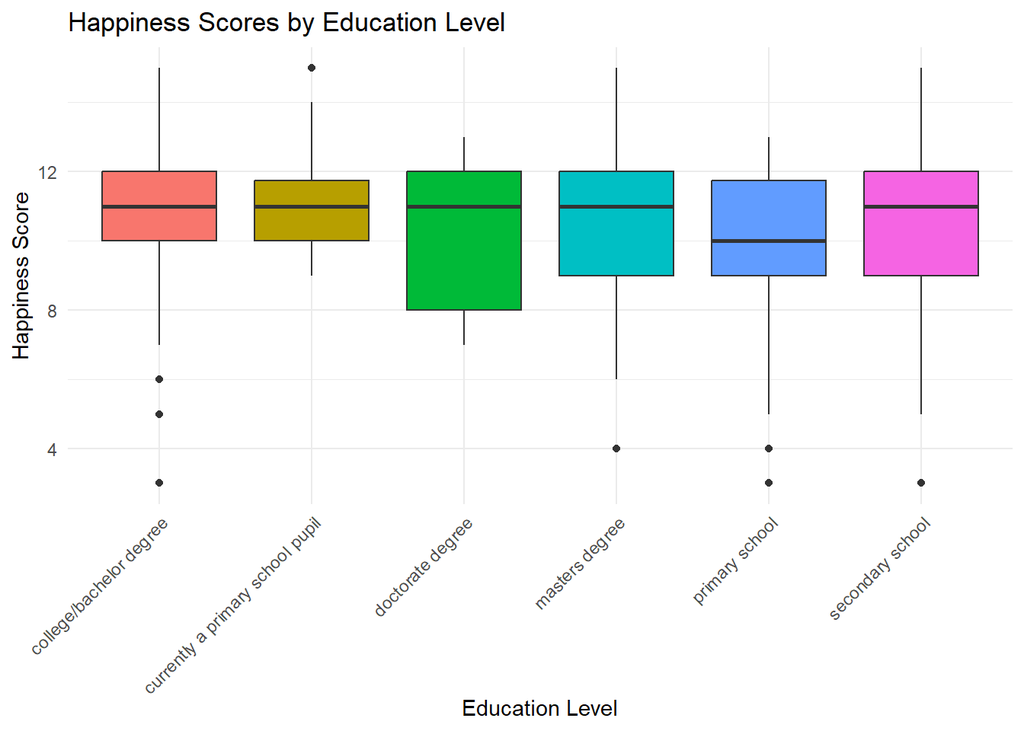

```r
education_clean <- happiness %>%
  filter(Happiness_score <= 15,
         Happiness_score >= 0,
         Education != "nunya business") %>%
  select(Education, Happiness_score)

ggplot(education_clean, aes(x = Education, y = Happiness_score, fill = Education)) +
  geom_boxplot() +
  labs(title = "Happiness Scores by Education Level",
       x = "Education Level",
       y = "Happiness Score") +
  theme_minimal() +
  theme(legend.position = "none",
        axis.text.x = element_text(angle = 45, hjust = 1))
```

```r
summary_stats_education <- favstats(Happiness_score ~ Education, data = education_clean)
```

What conclusions can you make?

**It appears that education does not make a significant difference on ones happiness score.**